# Deconvolution Analysis with CIBERSORT

Cristiane Esteves, Mariana Boroni - Bioinformatics and Computational Biology Lab (LBBC/INCA-RJ)

```r
#Set your work directory
setwd("~/Cancer_Genomics_Course/Modules/RNA_Deconvolution/Data_Deconvolution/")
```

```r
#Load Packages
suppressPackageStartupMessages({
  library(tibble)
  library(dplyr)
  library(ggplot2)
  library(survival)
  library(survminer)
  library(e1071)
  library(data.table)
  library(RColorBrewer)
  library(readr)
  library(reshape2)
})

#Load script CIBERSORT and barplot functions
source('bin/CIBERSORT.R')
source('bin/barplot_cibersort.R')
```

##Deconvolution Analysis - CIBERSORT

CIBERSORT is a deconvolution-based method that uses the v-support vector regression method (v-SVR) to estimate each immune cell type’s relative proportion from a gene expression profile. It requires an input of reference gene expression signatures. CIBERSORT provides a gene signature matrix (LM22.txt)(https://www.ncbi.nlm.nih.gov/pmc/articles/PMC4739640/). The file contains expression counts for 547 signature genes (547 rows) for 22 distinct human immune cells (22 columns).

The CIBERSORT source code and LM22 signature matrix are only freely available to academic users – register for access on the CIBERSORT website .

```r
#load the LM22 signatures
lm22_signatures <- as.data.frame(fread("data/lm22.txt"))
lm22_signatures <- tibble::column_to_rownames(lm22_signatures, "V1")
#Print the first six rows of LM22 signatures dataframe
print(head(lm22_signatures[,1:4]))
```

```
##        B cells naive B cells memory Plasma cells T cells CD8
## ABCB4      555.71345       10.74423     7.225819     4.31128
## ABCB9       15.60354       22.09479   653.392328    24.22372
## ACAP1      215.30595      321.62102    38.616872  1055.61338
## ACHE        15.11795       16.64885    22.123737    13.42829
## ACP5       605.89738     1935.20148  1120.104684   306.31252
## ADAM28    1943.74270     1148.12014   324.780800    22.68972
```

```r
#Print cell types present in the Lm22 signature
colnames(lm22_signatures)
```

```
##  [1] "B cells naive"                "B cells memory"
##  [3] "Plasma cells"                 "T cells CD8"
##  [5] "T cells CD4 naive"            "T cells CD4 memory resting"
##  [7] "T cells CD4 memory activated" "T cells follicular helper"
##  [9] "T cells regulatory (Tregs)"   "T cells gamma delta"
## [11] "NK cells resting"             "NK cells activated"
## [13] "Monocytes"                    "Macrophages M0"
## [15] "Macrophages M1"               "Macrophages M2"
## [17] "Dendritic cells resting"      "Dendritic cells activated"
## [19] "Mast cells resting"           "Mast cells activated"
## [21] "Eosinophils"                  "Neutrophils"
```

In this exercise, we will predict cell types in Bulk RNA matrix (SKCM-Metastasis). As input, we will use The Cancer Genome Atlas (TCGA) expression dataset from metastatic skin melanoma (TCGA-SKCM) as input. The file provided for this exercise have already been filtered to only contain genes that will be used by CIBERSORT. Obs.: The gene names must always be in the rownames, and it should match the reference.

```r
#Load the Bulk RNA TCGA-SKCM metastatic expression dataframe
#This dataframe has been alread filtered to only contain genes from lm22 signature that will be used by cibersort)
skcm_bulk <- as.data.frame(fread("data/bulk.txt"))
skcm_bulk <- tibble::column_to_rownames(skcm_bulk, "V1")
#Here we printing the first six rows of Bulk RNA TCGA-SKCM dataframe
print(head(skcm_bulk[,1:4]))
```

```
##        TCGA-EB-A5VV-06A-11R-A32P-07 TCGA-GN-A263-01A-11R-A18T-07
## ABCB4                        8.3243                       8.8439
## ABCB9                        1.1392                       0.6741
## ACAP1                      123.8629                       0.6941
## ACHE                        23.7050                       0.0790
## ACP5                        78.3980                      76.1972
## ADAM28                      43.5955                       0.5815
##        TCGA-HR-A2OG-06A-21R-A18U-07 TCGA-FS-A4F4-06A-12R-A266-07
## ABCB4                        1.8307                       1.3882
## ABCB9                        2.0190                       2.5264
## ACAP1                        6.3677                       2.7528
## ACHE                         1.1324                       1.1902
## ACP5                        66.2074                     132.7469
## ADAM28                       2.8839                       0.7676
```

CIBERSORT parameters:

1. perm = No. permutations; set to >=100 to calculate p-values (default = 0).
2. QN = Quantile normalization of input Patient_ID (default = TRUE) - (disabling is recommended for RNA-Seq data).
3. absolute = Run CIBERSORT in absolute mode (default = FALSE). The CIBERSORT absolute mode scales cellular fractions to a score that reflects each cell type’s absolute proportion, allowing comparison across both samples and cell types.

```r
# Here we are setting the seed to maintain the reproducibility of the results.
set.seed(42)
h1 <- Sys.time()
#Run CIBERSORT
#results.cibersort <- CIBERSORT(lm22_signatures, skcm_bulk, perm = 1, absolute = T, QN = F) #it is important to always use 100 or more permutations ("perm" parameter) but for didactic purposes, we will use perm = 1.
h2 <- Sys.time()
print(h2 - h1)
```

```
## Time difference of 0.001471996 secs
```

```r
#Filter for the significant predictions
#results.sign = as.data.frame(results.cibersort)[which(as.data.frame(results.cibersort)$`P-value` <= 0.05),]
#results.sign = results.sign[1:22]
```

```r
#for a interest of time, we will upload a pre-computed result
results.sign <- readRDS("data/results_cibersort_perm100.rds")

head(results.sign)
```

|  | B cells naive | B cells memory | Plasma cells | T cells CD8 | T cells CD4 naive | T cells CD4 memory resting | T cells CD4 memory activated | T cells follicular helper | T cells regulatory (Tregs) | T cells gamma delta | NK cells resting | NK cells activated | Monocytes | Macrophages M0 | Macrophages M1 | Macrophages M2 | Dendritic cells resting | Dendritic cells activated | Mast cells resting | Mast cells activated | Eosinophils | Neutrophils |
| --- | --- | --- | --- | --- | --- | --- | --- | --- | --- | --- | --- | --- | --- | --- | --- | --- | --- | --- | --- | --- | --- | --- |
| TCGA-EB-A5VV-06A-11R-A32P-07 | 0.216347096 | 0.15051420 | 0.012774596 | 0.09904092 | 0.03179635 | 0.07980637 | 0.000000000 | 0.03242889 | 0.159484680 | 0.00000000 | 0.0000000 | 0.09106491 | 0.01031261 | 0.02510181 | 0.034650997 | 0.03409341 | 0.00000000 | 0 | 0.000000000 | 0.02258316 | 0.000000000 | 0.00000000 |
| TCGA-HR-A2OG-06A-21R-A18U-07 | 0.007352887 | 0.00000000 | 0.156770100 | 0.06638627 | 0.00000000 | 0.03626144 | 0.010188486 | 0.02902367 | 0.028438921 | 0.00000000 | 0.0000000 | 0.07536845 | 0.01757906 | 0.34821248 | 0.046694460 | 0.13620108 | 0.00000000 | 0 | 0.000000000 | 0.02993065 | 0.000000000 | 0.01159204 |
| TCGA-FS-A4F4-06A-12R-A266-07 | 0.056646119 | 0.00000000 | 0.005620629 | 0.18667344 | 0.00000000 | 0.00000000 | 0.000000000 | 0.02421816 | 0.086364564 | 0.00000000 | 0.0000000 | 0.08302854 | 0.00000000 | 0.33271291 | 0.054220976 | 0.12931170 | 0.00000000 | 0 | 0.041202980 | 0.00000000 | 0.000000000 | 0.00000000 |
| TCGA-DA-A1HY-06A-11R-A18T-07 | 0.069765482 | 0.00000000 | 0.011530206 | 0.00000000 | 0.00000000 | 0.09231231 | 0.006846449 | 0.01577368 | 0.020442296 | 0.02765838 | 0.0380093 | 0.00000000 | 0.00000000 | 0.47440802 | 0.004787026 | 0.12600051 | 0.00000000 | 0 | 0.000000000 | 0.10616660 | 0.006299726 | 0.00000000 |
| TCGA-FS-A1YW-06A-11R-A18T-07 | 0.119936457 | 0.01125343 | 0.010138710 | 0.15114049 | 0.00000000 | 0.06680388 | 0.000000000 | 0.05697334 | 0.095280838 | 0.00000000 | 0.0000000 | 0.04045195 | 0.02646603 | 0.01869596 | 0.074131120 | 0.24053852 | 0.03954757 | 0 | 0.048641701 | 0.00000000 | 0.000000000 | 0.00000000 |
| TCGA-D3-A51T-06A-11R-A266-07 | 0.174537770 | 0.00000000 | 0.084998247 | 0.13868695 | 0.00000000 | 0.00000000 | 0.077786850 | 0.11573811 | 0.007427671 | 0.00000000 | 0.0000000 | 0.05080535 | 0.01770527 | 0.14772600 | 0.076664590 | 0.09449662 | 0.01156238 | 0 | 0.001864191 | 0.00000000 | 0.000000000 | 0.00000000 |

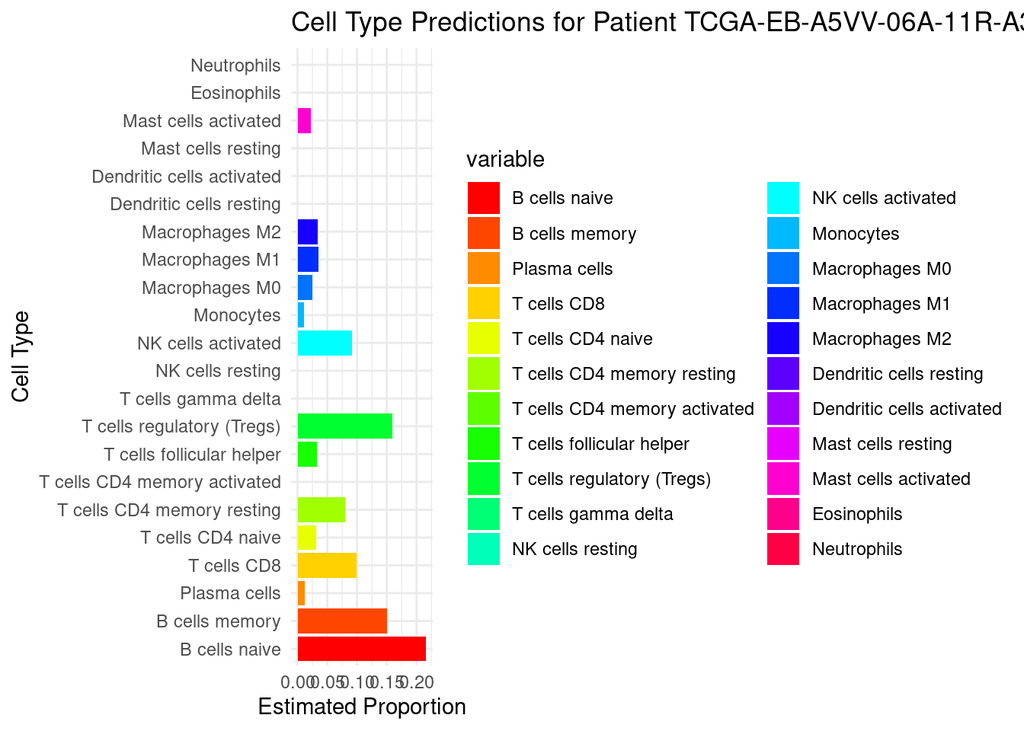

```r
# Transforming the data
results.sign$Patient_ID <- rownames(results.sign)

# Melting the data frame to long format for ggplot
results.sign_melt <- reshape2::melt(results.sign, id.vars = "Patient_ID", measure.vars = colnames(results.sign)[1:22])

# Choosing One Patient ID to plot
Patient_ID_indx <- results.sign_melt$Patient_ID == results.sign_melt$Patient_ID[1]

# Creating a 22 color palette
my_palette <- colorRampPalette(rainbow(22)) # Creating the palette function
palette_colors <- my_palette(22) # Generating 22 colors

# Plotting the cell types estimation for one sample
ggplot(results.sign_melt[Patient_ID_indx, ], aes(x = variable, y = value, fill = variable)) +
  geom_bar(stat = "identity") +
  coord_flip() +
  scale_fill_manual(values = palette_colors) +  # Applying the palette colors
  ggtitle(paste("Cell Type Predictions for Patient", results.sign_melt$Patient_ID[1])) +
  theme_minimal() +
  xlab("Cell Type") +
  ylab("Estimated Proportion")
```

## Association of cell types prediction and clinical outcomes

In the next section of our R Markdown document, we’re going to explore an exciting and crucial aspect of cancer research: the integration of cell type predictions from CIBERSORT with clinical data from TCGA. This step is vital as it allows us to understand how different cellular compositions in the tumor microenvironment relate to clinical outcomes. By associating specific cell types, as predicted by CIBERSORT, with various clinical parameters and patient data from TCGA, we can uncover valuable insights into how these cells influence the progression, treatment response, and overall prognosis of cancer.

```r
library(readr)

# Load Metastatic Melanoma (SKCM-TCGA) Clinical and Survival dataset

#data_SKCM a list format object that contains a dataframe of clinical and survival data
data_SKCM = readRDS("data/data_SKCM.rds")
head(data_SKCM$survival_met)
```

|  | bcr_patient_barcode | gender | race_list | ethnicity | age_at_initial_pathologic_diagnosis | submitted_tumor_location | Subtype_mRNA | Subtype_DNAmeth | Subtype_miRNA | Subtype_Mutation | vital_status.y | days_to_last_followup_met | days_to_death_met | tempo | survival_mel_met.State | OS | OS.time |
| --- | --- | --- | --- | --- | --- | --- | --- | --- | --- | --- | --- | --- | --- | --- | --- | --- | --- |
| 1 | TCGA-3N-A9WB | 1 | WHITE | NOT HISPANIC OR LATINO | 71 | Distant Metastasis | NA | NA | NA | NA | Dead | NA | 92 | 0.2518823 | 1 | 1 | 0.2518823 |
| 2 | TCGA-3N-A9WC | 1 | WHITE | NOT HISPANIC OR LATINO | 82 | Regional Lymph Node | NA | NA | NA | NA | Alive | 378 | NA | 1.0349076 | 0 | 0 | 1.0349076 |
| 3 | TCGA-3N-A9WD | 1 | WHITE | NOT HISPANIC OR LATINO | 82 | Regional Lymph Node | NA | NA | NA | NA | Dead | NA | 212 | 0.5804244 | 1 | 1 | 0.5804244 |
| 4 | TCGA-BF-AAP0 | 0 | WHITE | NOT HISPANIC OR LATINO | 40 | Regional Lymph Node | NA | NA | NA | NA | Alive | 454 | NA | 1.2429843 | 0 | 0 | 1.2429843 |
| 5 | TCGA-D3-A1Q1 | 0 | WHITE | NOT HISPANIC OR LATINO | 79 | Regional Lymph Node | keratin | hyper-methylated | MIR.type.4 | RAS | Dead | NA | 501 | 1.3716632 | 1 | 1 | 1.3716632 |
| 6 | TCGA-D3-A1Q3 | 1 | WHITE | NOT HISPANIC OR LATINO | 64 | Regional Lymph Node | immune | CpG island-methylated | MIR.type.4 | Triple_WT | Dead | NA | 259 | 0.7091034 | 1 | 1 | 0.7091034 |

```r
#Load the informations of the type molecular of tumor for each patient
subtypes <- read_csv("data/subtipos.csv", show_col_types = F)
head(subtypes)
```

| ...1 | pan.samplesID | cancer.type | Subtype_mRNA | Subtype_DNAmeth | Subtype_protein | Subtype_miRNA | Subtype_CNA | Subtype_Integrative | Subtype_other | Subtype_Selected |
| --- | --- | --- | --- | --- | --- | --- | --- | --- | --- | --- |
| 1 | TCGA-OR-A5J1 | ACC | steroid-phenotype-high+proliferation | CIMP-high | NA | miRNA_1 | Quiet | COC3 | C1A | ACC.CIMP-high |
| 2 | TCGA-OR-A5J2 | ACC | steroid-phenotype-high+proliferation | CIMP-low | 1 | miRNA_1 | Noisy | COC3 | C1A | ACC.CIMP-low |
| 3 | TCGA-OR-A5J3 | ACC | steroid-phenotype-high | CIMP-intermediate | 3 | miRNA_6 | Chromosomal | COC2 | C1A | ACC.CIMP-intermediate |
| 4 | TCGA-OR-A5J4 | ACC | NA | CIMP-high | NA | miRNA_6 | Chromosomal | NA | NA | ACC.CIMP-high |
| 5 | TCGA-OR-A5J5 | ACC | steroid-phenotype-high | CIMP-intermediate | NA | miRNA_2 | Chromosomal | COC2 | C1A | ACC.CIMP-intermediate |
| 6 | TCGA-OR-A5J6 | ACC | steroid-phenotype-low | CIMP-low | 2 | miRNA_1 | Noisy | COC1 | C1B | ACC.CIMP-low |

```r
#We need unique patient IDs  in rownames (in this dataset there is more than one sample per patient).
results.sign$Patient_ID <- rownames(results.sign)

#the gsub function will help us to replace the existing dots (.) in patient IDs to a dash (-).
results.sign$Patient_ID <- gsub("\\.", "-", results.sign$Patient_ID)
#Keep the first 12 characters of the patient ID.
results.sign$Patient_ID <- substr(results.sign$Patient_ID,1,12)

#Aggregate Cibersort result with clinical and survival data according to patient ID
forest_data <- left_join(results.sign,data_SKCM$survival_met[,c(1,8,16,17,2,5)], by= c("Patient_ID" = "bcr_patient_barcode"))
forest_data <- left_join(forest_data,subtypes[,c(2,10)], by= c("Patient_ID" = "pan.samplesID"))
#rename column to "Subtype_Mutation"
colnames(forest_data)[29] = "Subtype_Mutation"
```

### Plot Proportions of cell types predicted by Cibersort and compare between groups

```r
# Make Patient_ID column (Patient IDs from cibersort result table) as first column
res_cibersort = forest_data[, c("Patient_ID", colnames(forest_data)[1:22])]
res_cibersort$Patient_ID <- make.names(res_cibersort$Patient_ID, unique = T)
res_cibersort$Patient_ID <- gsub("\\.", "-", res_cibersort$Patient_ID)

# Check the columns (variable names) present in the clinical dataset
names(forest_data)
```

```
##  [1] "B cells naive"                       "B cells memory"
##  [3] "Plasma cells"                        "T cells CD8"
##  [5] "T cells CD4 naive"                   "T cells CD4 memory resting"
##  [7] "T cells CD4 memory activated"        "T cells follicular helper"
##  [9] "T cells regulatory (Tregs)"          "T cells gamma delta"
## [11] "NK cells resting"                    "NK cells activated"
## [13] "Monocytes"                           "Macrophages M0"
## [15] "Macrophages M1"                      "Macrophages M2"
## [17] "Dendritic cells resting"             "Dendritic cells activated"
## [19] "Mast cells resting"                  "Mast cells activated"
## [21] "Eosinophils"                         "Neutrophils"
## [23] "Patient_ID"                          "Subtype_DNAmeth"
## [25] "OS"                                  "OS.time"
## [27] "gender"                              "age_at_initial_pathologic_diagnosis"
## [29] "Subtype_Mutation"
```

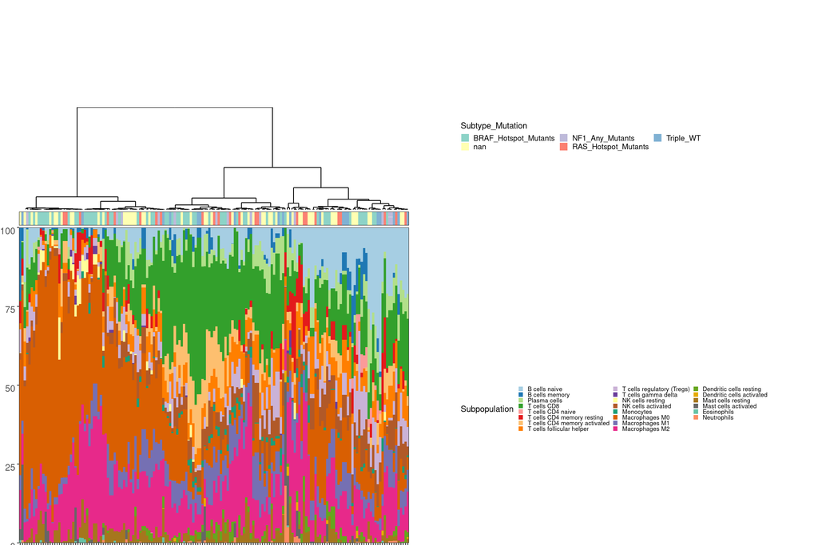

```r
## Lets create annotation data that will be also used to plot the final figure
#Filter for columns sample and Subtype mutation
data_barplot = forest_data[,c(23,29)]

#Make patient IDs unique values
data_barplot$Patient_ID <- make.names(data_barplot$Patient_ID, unique = T)
data_barplot$Patient_ID <- gsub("\\.", "-", data_barplot$Patient_ID)

# Put patient IDs in rownames
rownames(data_barplot) = data_barplot$Patient_ID
data_barplot$Patient_ID = NULL

# Add `NA` in empty fields
data_barplot$Subtype_Mutation[which(is.na(data_barplot$Subtype_Mutation))] <- "nan"
data_barplot$Subtype_Mutation[which(data_barplot$Subtype_Mutation == "-")] <- "nan"


#Plot the barplot: in which each column we have  a patient with the clinical informations on the first row (Subtype mutation, for example, colored according to legend colors) and each bar is divided by the proportion o immune cells types predicted by cibersort.

plot.ciber.heat(ciber.obj = res_cibersort, ann_info = data_barplot, sample.column = 1)
```

## Univariate and Multivariate Cox Regression analysis

The Cox proportional-hazards model (Cox, 1972) is essentially a regression model commonly used statistical in medical research for investigating the association between the survival time of patients and one or more predictor variables.

In clinical investigations, there are many situations, where several known quantities (known as covariates), potentially affect patient prognosis.

For instance, suppose two groups of patients are compared: those with and those without a specific genotype. If one of the groups also contains older individuals, any difference in survival may be attributable to genotype or age or indeed both. Hence, when investigating survival in relation to any one factor, it is often desirable to adjust for the impact of others.

Statistical model is a frequently used tool that allows to analyze survival with respect to several factors simultaneously. Additionally, statistical model provides the effect size for each factor.

The cox proportional-hazards model is one of the most important methods used for modelling survival analysis data. The next section introduces the basics of the Cox regression model.

References: http://www.sthda.com/english/wiki/cox-proportional-hazards-model

https://www.ncbi.nlm.nih.gov/pmc/articles/PMC2394262/

```r
library(dplyr)
library(survival)
# Univariate Cox
#Cox univariate analysis estimated the impact on survival of each cell type.
#For this, it is necessary to have the survival time of each patient and the event variable (in this case, death) and provide this information as input to the surv() function.

# Prepare the survival object
surv_object <- Surv(time = forest_data$OS.time, event = forest_data$OS)

# Replace spaces with underscores in column names (immune cell types and clinical variables)
#the gsub function will help us to replace the existing dots (.) in patient IDs to a dash (-).
colnames(forest_data)[1:22] <- gsub(" ", "_", colnames(forest_data)[1:22])

# Rename specific column if necessary
colnames(forest_data)[9] <- "Treg"

# Define the covariates for analysis
covariates <- colnames(forest_data)[c(1:22, 27:29)]
covariates
```

```
##  [1] "B_cells_naive"                       "B_cells_memory"
##  [3] "Plasma_cells"                        "T_cells_CD8"
##  [5] "T_cells_CD4_naive"                   "T_cells_CD4_memory_resting"
##  [7] "T_cells_CD4_memory_activated"        "T_cells_follicular_helper"
##  [9] "Treg"                                "T_cells_gamma_delta"
## [11] "NK_cells_resting"                    "NK_cells_activated"
## [13] "Monocytes"                           "Macrophages_M0"
## [15] "Macrophages_M1"                      "Macrophages_M2"
## [17] "Dendritic_cells_resting"             "Dendritic_cells_activated"
## [19] "Mast_cells_resting"                  "Mast_cells_activated"
## [21] "Eosinophils"                         "Neutrophils"
## [23] "gender"                              "age_at_initial_pathologic_diagnosis"
## [25] "Subtype_Mutation"
```

```r
# Function to create Cox model formulas by aggregating the column names that will be evaluated in the survival analysis by the surv() and coxph() function.
univ_formulas <- sapply(covariates, function(x) as.formula(paste('surv_object ~', x)))

# Apply Cox regression to each covariate using lapply function
univ_models <- lapply(univ_formulas, function(x){coxph(x, data = forest_data)})

# Extract important metrics from each Cox model (p-value, hazard ratios, confidence intervals) and format them.
univ_results <- lapply(univ_models,
                              function(x){
                                x <- summary(x)
                                p.value<-signif(x$wald["pvalue"], digits=2)
                                wald.test<-signif(x$wald["test"], digits=2)
                                beta<-signif(x$coef[1], digits=2);#coeficient beta

                                HR <-signif(x$coef[2], digits=2);#exp(beta)
                                HR.confint.lower <- signif(x$conf.int[,"lower .95"], 2)
                                HR.confint.upper <- signif(x$conf.int[,"upper .95"],2)
                                HR <- paste0(HR, " (",
                                             HR.confint.lower, "-", HR.confint.upper, ")")
                                res<-c(beta, HR, wald.test, p.value)
                                names(res)<-c("beta", "HR (95% CI for HR)", "wald.test",
                                              "p.value")
                                return(res)
                              })


#Transform the list (univ_results) object into dataframe
res_cox = as.data.frame(t(do.call(cbind, univ_results)))
#Transform pvalue column into character and numeric
res_cox$p.value <- as.character(res_cox$p.value)
res_cox$p.value <- as.numeric(res_cox$p.value)
```

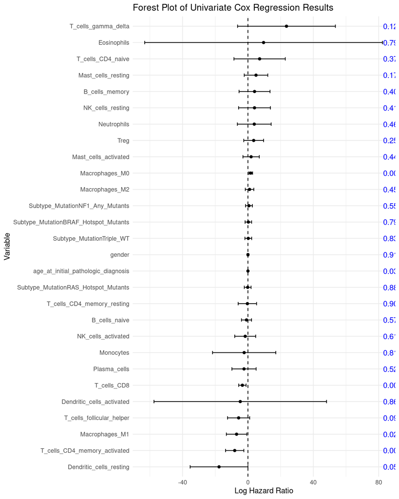

```r
### Lets visualize the results:
# Convert individual univariate results to a data frame
univ_results_df <- do.call(rbind, lapply(univ_models, function(model) {
  model_sum <- summary(model)
  term <- rownames(model_sum$coefficients)
  HR <- exp(model_sum$coefficients[, "coef"])
  lower_CI <- exp(model_sum$coefficients[, "coef"] - 1.96 * model_sum$coefficients[, "se(coef)"])
  upper_CI <- exp(model_sum$coefficients[, "coef"] + 1.96 * model_sum$coefficients[, "se(coef)"])
  p_value <- model_sum$coefficients[, "Pr(>|z|)"]

  data.frame(Term = term, HR = HR, lower_CI = lower_CI, upper_CI = upper_CI, p_value = p_value)
}))

# Adjusting the rownames
rownames(univ_results_df) <- NULL


# Add a column for formatted p-values
univ_results_df$p_value_formatted <- ifelse(univ_results_df$p_value < 0.001, "< 0.001",
                                            formatC(univ_results_df$p_value, format = "f", digits = 3))

# Find the maximum x-value for positioning the p-values
max_x_value <- max(log(univ_results_df$upper_CI))

# Set an offset (adjust as needed based on your plot)
offset <- 0.5

# Creating the forest plot
ggplot(univ_results_df, aes(x = log(HR), y = reorder(Term, log(HR)))) +
  geom_point() +
  geom_errorbarh(aes(xmin = log(lower_CI), xmax = log(upper_CI)), height = 0.2) +
  geom_vline(xintercept = 0, linetype = "dashed") +
  geom_text(aes(label = p_value_formatted, x = max_x_value + offset), hjust = 0, color = "blue") +
  theme_minimal() +
  labs(title = "Forest Plot of Univariate Cox Regression Results",
       x = "Log Hazard Ratio",
       y = "Variable") +
  theme(axis.text.y = element_text(hjust = 1))
```

Multivariate Analysis

```r
#Now, we want to describe how the factors jointly impact on survival. To answer to this question, we’ll perform an statistical test called multivariate Cox regression analysis. For this, we select only the features that were significant in the univariate anaylis

#Filtering Significant Results: You filter out results where the p-value is greater than 0.05.
significant_results <- res_cox[which(res_cox$p.value <= 0.05),]

#Check the immune cells that significantly impact each patient's survival (p val =<0.05)
significant_results
```

|  | beta | HR (95% CI for HR) | wald.test | p.value | None | None | None |
| --- | --- | --- | --- | --- | --- | --- | --- |
| T_cells_CD8 | -3.4 | 0.034 (0.0035-0.32) | 8.7 | 0.0032 | -3.4 | 0.034 (0.0035-0.32) | 8.7 |
| T_cells_CD4_memory_activated | -8.1 | 3e-04 (1.1e-06-0.083) | 8 | 0.0046 | -8.1 | 3e-04 (1.1e-06-0.083) | 8 |
| Macrophages_M0 | 1.7 | 5.7 (1.9-17) | 9.2 | 0.0024 | 1.7 | 5.7 (1.9-17) | 9.2 |
| Macrophages_M1 | -6.9 | 0.00096 (1.8e-06-0.5) | 4.8 | 0.0290 | -6.9 | 0.00096 (1.8e-06-0.5) | 4.8 |
| Dendritic_cells_resting | -18 | 2.1e-08 (4.5e-16-1) | 3.8 | 0.0500 | -18 | 2.1e-08 (4.5e-16-1) | 3.8 |
| age_at_initial_pathologic_diagnosis | 0.018 | 1 (1-1) | 4.7 | 0.0310 | 0.018 | 1 (1-1) | 4.7 |

```r
# Creating a formula for the multivariate analysis, combining significant factors
f1 <- as.formula(paste("Surv(forest_data$OS.time, event = forest_data$OS) ~ ",
                       paste(rownames(significant_results), collapse= "+")))
# Performing multivariate Cox regression
fit.coxph <- coxph(f1, data = forest_data)

# Summarizing the multivariate Cox model
summary(fit.coxph)
```

```
## Call:
## coxph(formula = f1, data = forest_data)
##
##   n= 152, number of events= 72
##    (17 observations deleted due to missingness)
##
##                                           coef  exp(coef)   se(coef)      z
## T_cells_CD8                         -0.5228794  0.5928111  1.6879367 -0.310
## T_cells_CD4_memory_activated        -5.4836476  0.0041541  3.5221332 -1.557
## Macrophages_M0                       0.5030941  1.6538304  0.9187906  0.548
## Macrophages_M1                      -4.3330880  0.0131269  3.7069023 -1.169
## Dendritic_cells_resting             -7.7030218  0.0004515  9.2760154 -0.830
## age_at_initial_pathologic_diagnosis  0.0178737  1.0180344  0.0083618  2.138
##                                     Pr(>|z|)
## T_cells_CD8                           0.7567
## T_cells_CD4_memory_activated          0.1195
## Macrophages_M0                        0.5840
## Macrophages_M1                        0.2424
## Dendritic_cells_resting               0.4063
## age_at_initial_pathologic_diagnosis   0.0326 *
## ---
## Signif. codes:  0 '***' 0.001 '**' 0.01 '*' 0.05 '.' 0.1 ' ' 1
##
##                                     exp(coef) exp(-coef) lower .95 upper .95
## T_cells_CD8                         0.5928111     1.6869 2.168e-02    16.207
## T_cells_CD4_memory_activated        0.0041541   240.7232 4.173e-06     4.135
## Macrophages_M0                      1.6538304     0.6047 2.732e-01    10.013
## Macrophages_M1                      0.0131269    76.1792 9.180e-06    18.771
## Dendritic_cells_resting             0.0004515  2215.0313 5.739e-12 35512.295
## age_at_initial_pathologic_diagnosis 1.0180344     0.9823 1.001e+00     1.035
##
## Concordance= 0.693  (se = 0.031 )
## Likelihood ratio test= 20.11  on 6 df,   p=0.003
## Wald test            = 17.66  on 6 df,   p=0.007
## Score (logrank) test = 18.7  on 6 df,   p=0.005
```

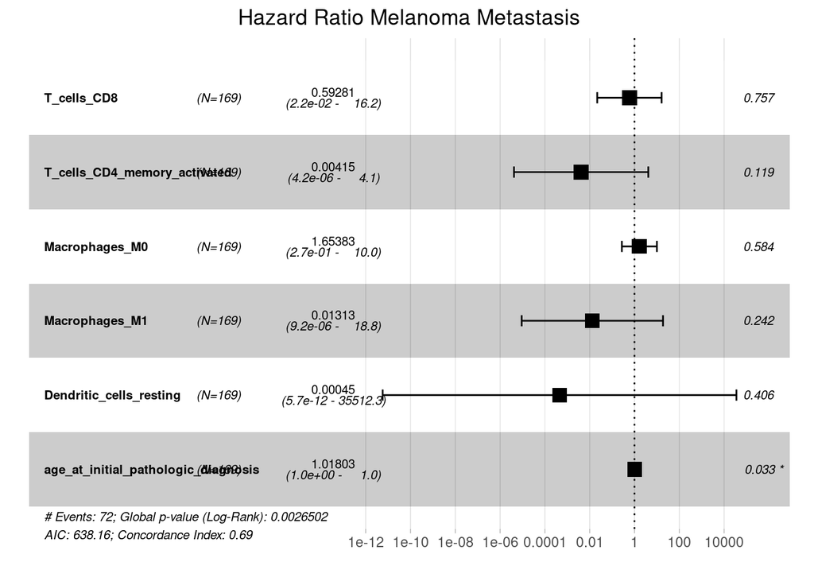

```r
#Lets Plot the Forest plot
ggforest(fit.coxph, data = forest_data, main = "Hazard Ratio Melanoma Metastasis")
```